# Technical Document

### Mapping Data

```r
#Read in data
df <- read_csv("AAData.csv")
# Geocode addresses with (Commented out in order to prevent GoogleMaps API limit from being reached)

# latlng <- df %>%
#      select(address) %>%
#      unlist(use.names = F) %>%
#      geocode() %>%
#      rename(lng = lon)
#
# # Separately geocode for Washington State University (NA originally)
# latlng[120, ] <- geocode("French Administration Building, Pullman, WA")
#
# latlng <- latlng[c("lat", "lng")]
# write.csv(latlng, file = "latlng")
```

Leaflet map which plots the locations of all the D1 schools, with clustering for nearby schools. Created in order to show the distribution of D1 schools in an interesting medium. Labels added for the school names.

```r
latlng <- read_csv("latlng")
```

```r
df <- df %>%
    mutate(lat = latlng$lat, lng = latlng$lng)

# Create leaflet map and add markeres with school names, add clustering
clusteredMap <- df %>%
    leaflet() %>%
    addTiles() %>%
    addMarkers(label = df$institution_name, popup = df$institution_name, clusterOptions = markerClusterOptions()) %>%
    setView(-98.585522, 39.8333333, zoom = 4)
```

```
## Assuming 'lng' and 'lat' are longitude and latitude, respectively
```

```r
clusteredMap
```

[interactive chart not shown]

Leaflet map which plots the locations of all the D1 schools (without clustering).

```r
# Create leaflet map and add markeres with school names
unclusteredMap <- leaflet() %>%
    addTiles() %>%
    addMarkers(data = df, label = df$institution_name) %>%
    setView(-98.585522, 39.8333333, zoom = 4)
```

```
## Assuming 'lng' and 'lat' are longitude and latitude, respectively
```

```r
unclusteredMap
```

[interactive chart not shown]

Exploratory Classification - Used to initially determine if classifying schools as Profitable/Not Profitable was feasible

```r
#Gathering EADA 2016 Data for Classification, define isProfitable if reveneus exceeded expenses
ClassificationProfitable <- read_csv("EADA2016.csv") %>%
    unite(address, addr1_txt, city_txt, state_cd, zip_text, sep = ", ", remove = FALSE) %>%
    mutate(GRAND_TOTAL_PROFIT = GRND_TOTAL_REVENUE - GRND_TOTAL_EXPENSE, isProfitable = (GRAND_TOTAL_PROFIT > 0))
```

Explore two possible ways by which to classify the data. The first classification relates the total recruiting expenditures to the head coach salaries of men’s teams.

The second classification relates the number of males students at a university to the number of female students.

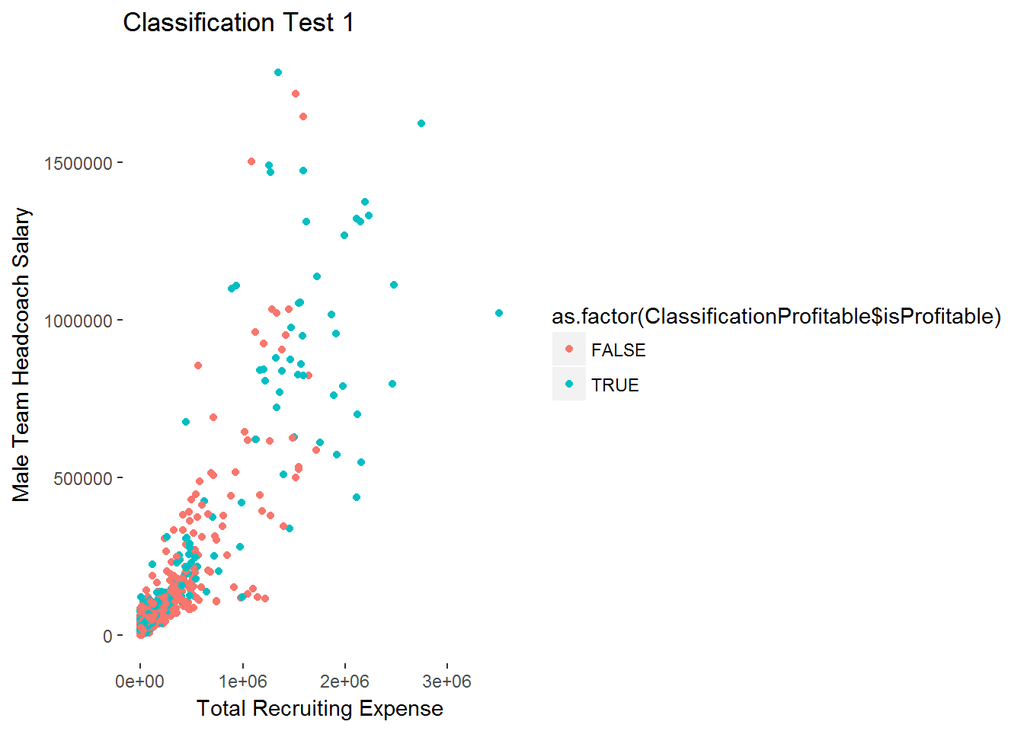

```r
# ClassificationProfitable %>%
#     ggplot() +
#     geom_point(aes(x = ClassificationProfitable$EFTotalCount, y = ClassificationProfitable$HDCOACH_SALARY_COED, colour = as.factor(ClassificationProfitable$isProfitable))) +
#     theme(panel.background = element_blank())
#
# ClassificationProfitable %>%
#     ggplot() +
#     geom_point(aes(x = ClassificationProfitable$EFTotalCount, y = ClassificationProfitable$STUDENTAID_TOTAL, colour = as.factor(ClassificationProfitable$isProfitable))) + theme(panel.background = element_blank())
#
# ClassificationProfitable %>%
#     ggplot() +
#     geom_point(aes(x = ClassificationProfitable$FTE_HDCOACH_MEN, y = ClassificationProfitable$ASCOACH_SAL_FTE_MEN, colour = as.factor(ClassificationProfitable$isProfitable))) + theme(panel.background = element_blank())
#
#
# ClassificationProfitable %>%
#     ggplot() +
#     geom_point(aes(x = ClassificationProfitable$NUM_HDCOACH_MEN + ClassificationProfitable$NUM_HDCOACH_WOMEN, y = ClassificationProfitable$HDCOACH_SAL_FTE_MEN + ClassificationProfitable$HDCOACH_SAL_FTE_WOMN, colour = as.factor(ClassificationProfitable$isProfitable))) + theme(panel.background = element_blank())

ClassificationProfitable %>%
    ggplot() +
    geom_point(aes(x = ClassificationProfitable$RECRUITEXP_TOTAL, y = ClassificationProfitable$HDCOACH_SALARY_MEN, colour = as.factor(ClassificationProfitable$isProfitable))) + theme(panel.background = element_blank()) +
     ggtitle("Classification Test 1 ") +
    labs(x = 'Total Recruiting Expense', y ='Male Team Headcoach Salary')
```

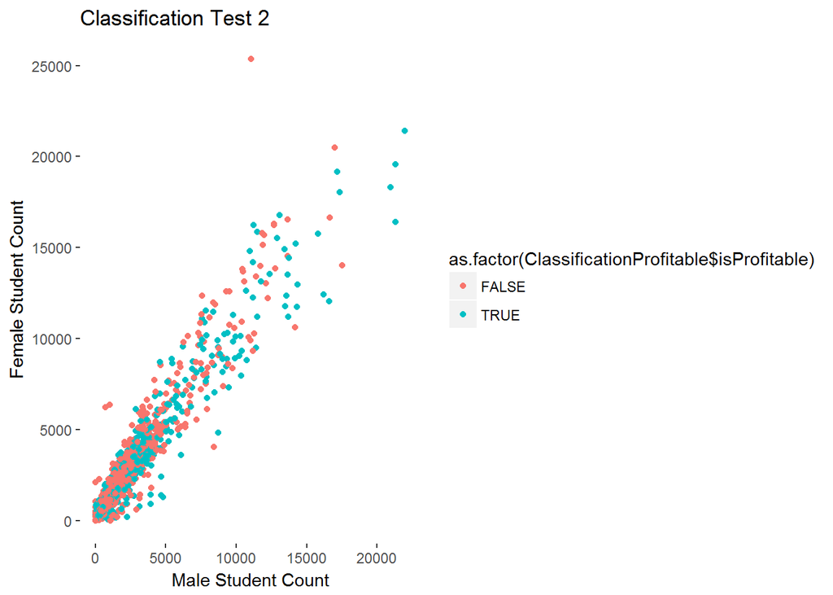

```r
ClassificationProfitable %>%
    ggplot() +
    geom_jitter(aes(x = ClassificationProfitable$EFMaleCount, y = ClassificationProfitable$EFFemaleCount, colour = as.factor(ClassificationProfitable$isProfitable))) + theme(panel.background = element_blank()) +
    ggtitle("Classification Test 2 ") +
    labs(x = 'Male Student Count', y ='Female Student Count')
```

Further Analysis

Collecting only Division I Schools

```r
AcademicAthleticInitial <- read_csv('EADA2016.csv')
AAData <- AcademicAthleticInitial
AAData <- filter(AAData, ClassificationCode <= 3)
```

Variables Only Including Spending, Revenue, Profit

```r
AAData <- AAData %>%
    unite(address, addr1_txt, city_txt, state_cd, zip_text, sep = ", ", remove = FALSE)
```

Selecting necessary variables for analysis

```r
AAData <- AAData %>%
    select(unitid, institution_name, address, ClassificationCode, EFMaleCount, EFFemaleCount, EFTotalCount, sector_cd, STUDENTAID_TOTAL, RECRUITEXP_TOTAL, HDCOACH_SALARY_MEN, HDCOACH_SALARY_WOMEN, GRND_TOTAL_REVENUE, GRND_TOTAL_EXPENSE, PARTIC_MEN_Baseball, PARTIC_MEN_Bskball, PARTIC_MEN_Football, PARTIC_WOMEN_Softball, PARTIC_WOMEN_Bskball, TOTAL_OPEXP_MENWOMEN_Baseball, TOTAL_OPEXP_MENWOMEN_Bskball, TOTAL_OPEXP_MENWOMEN_Football, TOTAL_REV_MENWOMEN_Baseball, TOTAL_REV_MENWOMEN_Bskball, TOTAL_REV_MENWOMEN_Football, TOTAL_EXP_MENWOMEN_Baseball, TOTAL_EXP_MENWOMEN_Bskball, TOTAL_EXP_MENWOMEN_Football)
```

Minor Data Manipulation

```r
AAData <- mutate(AAData, GRAND_TOTAL_PROFIT = GRND_TOTAL_REVENUE - GRND_TOTAL_EXPENSE)
AAData <- mutate(AAData, PARTIC_TOTAL_Baseball = PARTIC_MEN_Baseball + PARTIC_WOMEN_Softball)
AAData <- mutate(AAData, PARTIC_TOTAL_Bskball = PARTIC_MEN_Bskball + PARTIC_WOMEN_Bskball)
AAData <- mutate(AAData, PARTIC_TOTAL_Football = PARTIC_MEN_Football)

AATest <- AAData
```

Creating a new dataset ‘football’ which contains only Classification Codes = 1

```r
football <- filter(AAData, ClassificationCode == 1)
```

Plots describing the profitability of D1 Schools, and just FBS schools. Creating plot of the amounts of profit by individual schools schools

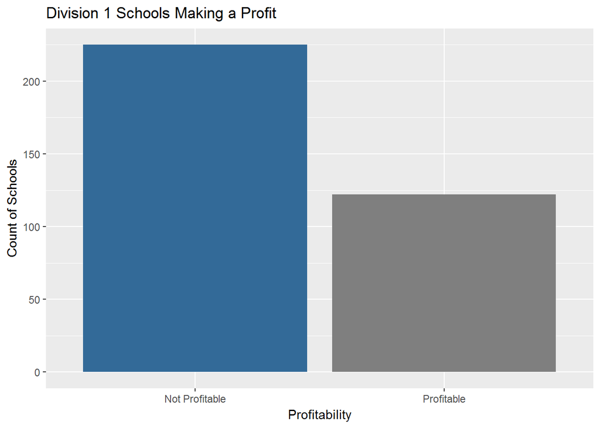

```r
ggplot(AAData, aes(x = GRAND_TOTAL_PROFIT > 0, fill = GRAND_TOTAL_PROFIT )) +
  geom_bar(show.legend = FALSE) +
  scale_x_discrete(labels = c("FALSE" = "Not Profitable", "TRUE" = "Profitable")) +
  ggtitle('Division 1 Schools Making a Profit') +
  labs(x = 'Profitability', y = 'Count of Schools')
```

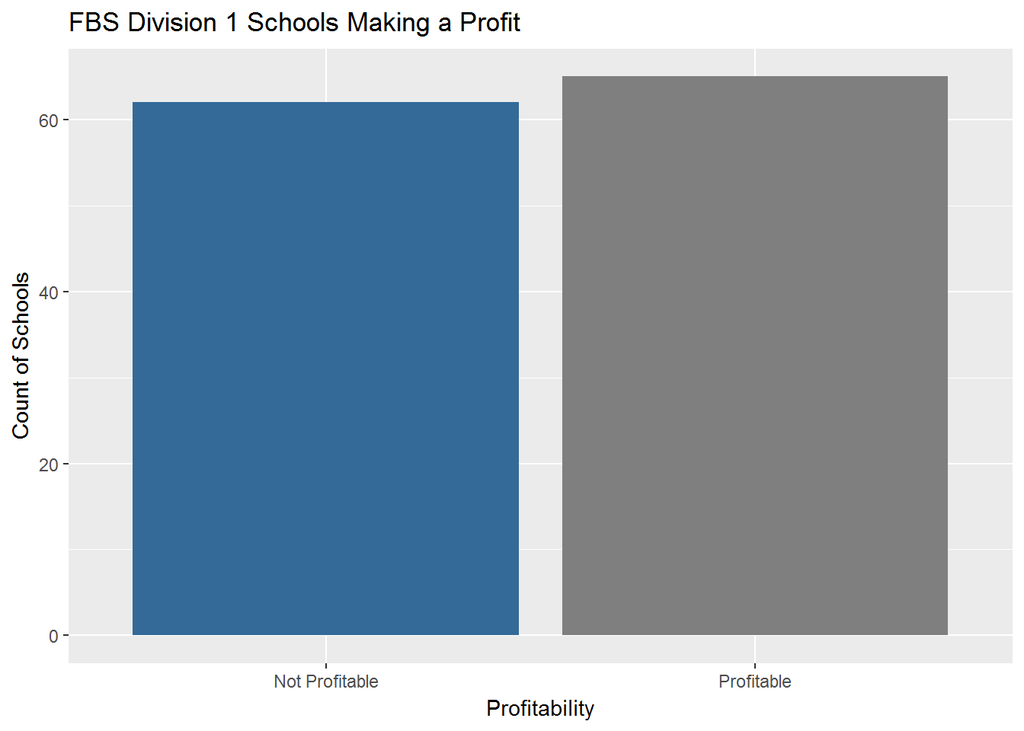

```r
ggplot(football, aes(x = GRAND_TOTAL_PROFIT > 0, fill = GRAND_TOTAL_PROFIT)) +
  geom_bar(show.legend = FALSE) +
  scale_x_discrete(labels = c("FALSE" = "Not Profitable", "TRUE" = "Profitable")) +
  ggtitle('FBS Division 1 Schools Making a Profit') +
  labs(x = 'Profitability', y = 'Count of Schools')
```

[figure not shown]

```r
profit_football <- filter(football, GRAND_TOTAL_PROFIT > 0)
ggplot(profit_football, aes(GRAND_TOTAL_PROFIT)) +
  geom_histogram(bins = 100) +
  ggtitle('FBS Division 1 Schools Profits')+
  labs(x = 'Amount of Profit', y = 'Count') +
  scale_x_continuous(breaks = c(0e+07, 1e+07, 2e+07, 3e+07), label = c("$0", "$1,000,000", "$2,000,000", "$3,000,000"))
```